# PCIT-CoS-Waitlist RCT Paper 1: DECA Attachment ASD

Nancy Briggs

05 JAN 2021

### DECA Attachment Adjusting for ASD

#### Descriptives

| asdcase | group | time | n | mean | sd | median | min | max |
| --- | --- | --- | --- | --- | --- | --- | --- | --- |
| 0 | 1 | 1 | 24 | 38.58333 | 7.045916 | 38.0 | 28 | 54 |
| 0 | 1 | 2 | 17 | 39.52941 | 8.063170 | 35.0 | 29 | 52 |
| 0 | 1 | 3 | 14 | 39.57143 | 6.824326 | 39.0 | 30 | 50 |
| 0 | 2 | 1 | 24 | 43.66667 | 6.105355 | 42.5 | 33 | 57 |
| 0 | 2 | 2 | 9 | 38.00000 | 7.968689 | 35.0 | 28 | 53 |
| 0 | 2 | 3 | 5 | 39.40000 | 9.502631 | 35.0 | 29 | 50 |
| 0 | 3 | 1 | 25 | 45.52000 | 8.302209 | 45.0 | 28 | 65 |
| 0 | 3 | 2 | 22 | 41.27273 | 8.827348 | 39.0 | 28 | 57 |
| 0 | 3 | 3 | 0 | NaN | NA | NA | Inf | -Inf |
| 1 | 1 | 1 | 6 | 34.16667 | 6.013873 | 34.0 | 28 | 44 |
| 1 | 1 | 2 | 5 | 37.80000 | 12.029131 | 35.0 | 28 | 57 |
| 1 | 1 | 3 | 5 | 29.40000 | 2.607681 | 28.0 | 28 | 34 |
| 1 | 2 | 1 | 3 | 29.00000 | 1.000000 | 29.0 | 28 | 30 |
| 1 | 2 | 2 | 2 | 35.00000 | 9.899495 | 35.0 | 28 | 42 |
| 1 | 2 | 3 | 0 | NaN | NA | NA | Inf | -Inf |
| 1 | 3 | 1 | 5 | 33.80000 | 4.816638 | 31.0 | 29 | 39 |
| 1 | 3 | 2 | 4 | 30.75000 | 3.201562 | 30.5 | 28 | 34 |
| 1 | 3 | 3 | 0 | NaN | NA | NA | Inf | -Inf |

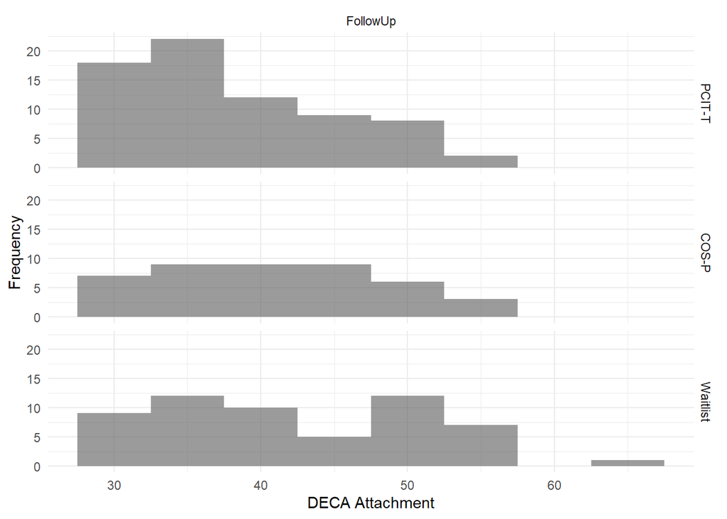

#### Model & Results

A linear mixed model with random effect for individual and fixed effects of group, time and the interaction was run. ASD status was then entered into the model as a main effect and then the 3-way interaction. Estimated marginal means were obtained, and contrasts specified to test Hypothesis 1 and Hypothesis 2.

```
## fixed-effect model matrix is rank deficient so dropping 1 column / coefficient
```

```
## fixed-effect model matrix is rank deficient so dropping 3 columns / coefficients
```

This is the ANOVA table for the model. p-values are likelihood ratio tests for adding the new term to the model just before. A p-value <0.05 indicates that adding that term results in better model fit. The most important p-value is the interaction p-value.

```
## refitting model(s) with ML (instead of REML)
```

[output not shown]

There is no evidence that ASD moderates the 2-way group*time interaction the 3-way interaction (p=0.153).

Model3, the model with Group*Time, adjusted by ASD will be the model I use for Estimated Means.

```r
summary(result3)
```

```
## Linear mixed model fit by REML. t-tests use Satterthwaite's method [
## lmerModLmerTest]
## Formula: outcome ~ asdcase + group * time + (1 | id)
##    Data: dat
##
## REML criterion at convergence: 1127.4
##
## Scaled residuals:
##     Min      1Q  Median      3Q     Max
## -1.8153 -0.5914 -0.1064  0.5686  2.6288
##
## Random effects:
##  Groups   Name        Variance Std.Dev.
##  id       (Intercept) 17.85    4.225
##  Residual             39.97    6.322
## Number of obs: 170, groups:  id, 87
##
## Fixed effects:
##              Estimate Std. Error      df t value Pr(>|t|)
## (Intercept)    39.358      1.435 140.218  27.426  < 2e-16 ***
## asdcase1       -8.290      1.816  73.839  -4.566 1.95e-05 ***
## group2          3.600      2.024 144.162   1.779  0.07734 .
## group3          5.590      1.964 144.519   2.846  0.00507 **
## time2           1.391      1.815  93.595   0.766  0.44543
## time3          -1.090      1.911  96.221  -0.571  0.56964
## group2:time2   -4.827      3.009 105.690  -1.604  0.11173
## group3:time2   -5.226      2.496  90.973  -2.094  0.03905 *
## group2:time3   -2.453      3.855 113.564  -0.636  0.52581
## ---
## Signif. codes:  0 '***' 0.001 '**' 0.01 '*' 0.05 '.' 0.1 ' ' 1
##
## Correlation of Fixed Effects:
##             (Intr) asdcs1 group2 group3 time2  time3  grp2:2 grp3:2
## asdcase1    -0.253
## group2      -0.684  0.080
## group3      -0.692  0.031  0.487
## time2       -0.507 -0.017  0.361  0.373
## time3       -0.477 -0.034  0.342  0.354  0.419
## group2:tim2  0.313 -0.019 -0.463 -0.226 -0.603 -0.252
## group3:tim2  0.367  0.019 -0.262 -0.543 -0.727 -0.305  0.438
## group2:tim3  0.230  0.042 -0.357 -0.175 -0.208 -0.497  0.291  0.152
## fit warnings:
## fixed-effect model matrix is rank deficient so dropping 1 column / coefficient
```

#### Estimated Means & Change

Estimated means for each Treatment and Time (adjusted by ASD status) are presented. In addition, within-group change between time points is presented with 95% CIs.

##### Group mean difference at each timepoint

Group Differences at Each Time Point

| Group Difference | Time | Mean | SE | t | p | adj p | Lower CL | Upper CL | Effect Size | Lower CL | Upper CL |
| --- | --- | --- | --- | --- | --- | --- | --- | --- | --- | --- | --- |
| 1 - 2 | 1 | -3.600 | 2.024 | -1.779 | 0.180 | 0.232 | -8.393 | 1.192 | -0.500 | -1.104 | -0.014 |
| 1 - 3 | 1 | -5.590 | 1.964 | -2.846 | 0.014 | 0.015 | -10.242 | -0.938 | -0.777 | -1.329 | -0.162 |
| 2 - 3 | 1 | -1.990 | 2.020 | -0.985 | 0.587 | 0.978 | -6.773 | 2.793 | -0.277 | -0.701 | 0.315 |
| 1 - 2 | 2 | 1.226 | 2.754 | 0.445 | 0.897 | 1.000 | -5.289 | 7.742 | 0.170 | -0.709 | 0.754 |
| 1 - 3 | 2 | -0.364 | 2.187 | -0.167 | 0.985 | 1.000 | -5.541 | 4.812 | -0.051 | -0.719 | 0.383 |
| 2 - 3 | 2 | -1.591 | 2.684 | -0.593 | 0.824 | 1.000 | -7.941 | 4.759 | -0.221 | -0.896 | 0.516 |
| 1 - 2 | 3 | -1.147 | 3.686 | -0.311 | 0.948 | 1.000 | -9.870 | 7.576 | -0.159 | -1.300 | 0.620 |
| 1 - 3 | 3 | NA | NA | NA | NA | NA | NA | NA | NA | NA | NA |
| 2 - 3 | 3 | NA | NA | NA | NA | NA | NA | NA | NA | NA | NA |

* Effect size scaled by pooled T1 SD  
† ES 95% Bootstrapped Percentile CI limits  
‡ If you want a positive ES (and it is calculated as negative), be sure to switch the signs and positions of the lower and upper CIs.

##### Change within each group

Within-Group Change and Effect Sizes

| Change | Group | Mean | SE | t | p | adj p | Lower CL | Upper CL | Effect Size | Lower CL | Upper CL |
| --- | --- | --- | --- | --- | --- | --- | --- | --- | --- | --- | --- |
| 1 - 2 | 1 | -1.391 | 1.819 | -0.765 | 0.726 | 1.000 | -5.723 | 2.942 | -0.193 | -0.626 | 0.276 |
| 1 - 3 | 1 | 1.090 | 1.917 | 0.569 | 0.837 | 1.000 | -3.473 | 5.654 | 0.151 | -0.327 | 0.642 |
| 2 - 3 | 1 | 2.481 | 2.012 | 1.233 | 0.437 | 0.663 | -2.317 | 7.279 | 0.345 | -0.149 | 0.776 |
| 1 - 2 | 2 | 3.436 | 2.415 | 1.423 | 0.333 | 0.473 | -2.300 | 9.172 | 0.477 | -0.126 | 1.066 |
| 1 - 3 | 2 | 3.544 | 3.373 | 1.051 | 0.547 | 0.887 | -4.462 | 11.550 | 0.492 | -0.403 | 1.281 |
| 2 - 3 | 2 | 0.108 | 3.645 | 0.030 | 1.000 | 1.000 | -8.557 | 8.772 | 0.015 | -0.952 | 0.889 |
| 1 - 2 | 3 | 3.835 | 1.715 | 2.237 | 0.071 | 0.084 | -0.253 | 7.923 | 0.533 | 0.008 | 0.899 |
| 1 - 3 | 3 | NA | NA | NA | NA | NA | NA | NA | NA | NA | NA |
| 2 - 3 | 3 | NA | NA | NA | NA | NA | NA | NA | NA | NA | NA |

* Effect size scaled by pooled T1 SD  
† ES 95% Bootstrapped Percentile CI limits  
‡ If you want a positive ES (and it is calculated as negative), be sure to switch the signs and positions of the lower and upper CIs.

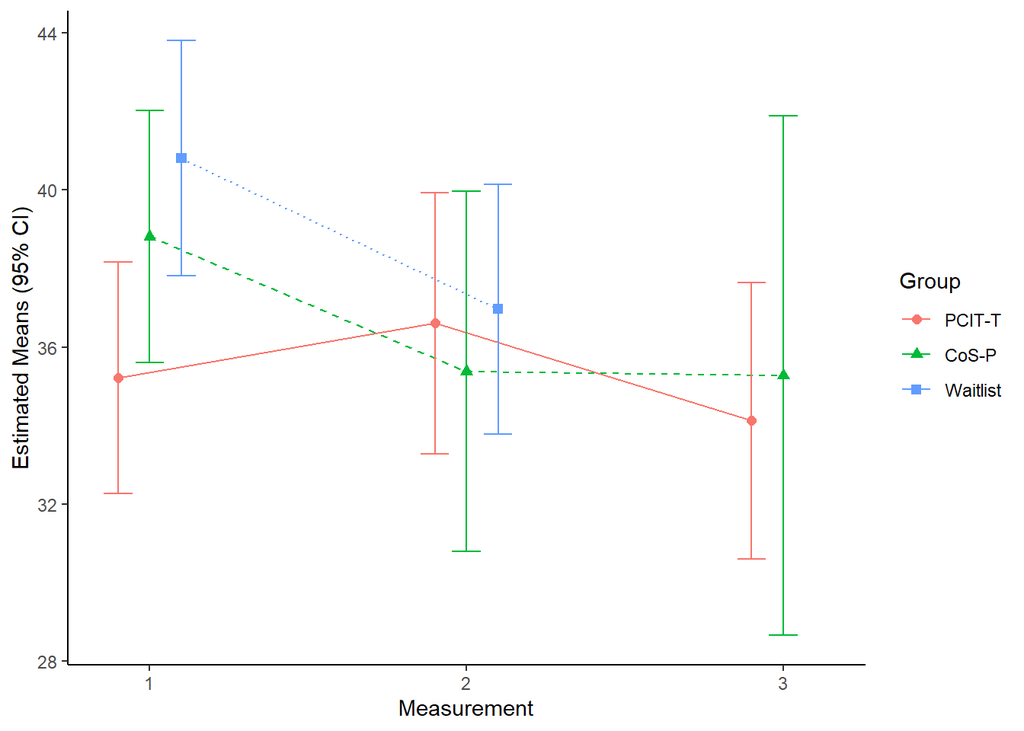

#### Hypothesis 1

We hypothesize that from baseline (‘T1’) to post-treatment/waitlist (‘T2’) there will be a gradient effect, whereby parent-child dyads who receive PCIT-T will show the greatest gains and parent-child dyads who receive no treatment will show the least gains. For the outcome, then, the null hypothesis is:

$H_0: \text {mean change}(\text{PCIT-T}) = \text {mean change}(\text{CoS-P}) = \text {mean change}(\text{Waitlist})$ $H_A: \text {mean change}(\text{PCIT-T}) > \text {mean change}(\text{CoS-P}) > \text {mean change}(\text{Waitlist})$

This is a joint hypothesis test.

First, confirming that the ordering of the means is as hypothesized:

```
## group = 1:
##  contrast estimate   SE    df t.ratio p.value
##  1 - 2      -1.391 1.82  92.8  -0.765  0.7255
##  1 - 3       1.090 1.92  95.5   0.569  0.8370
##  2 - 3       2.481 2.01  87.5   1.233  0.4371
##
## group = 2:
##  contrast estimate   SE    df t.ratio p.value
##  1 - 2       3.436 2.41 112.2   1.423  0.3327
##  1 - 3       3.544 3.37 119.2   1.051  0.5466
##  2 - 3       0.108 3.65 106.4   0.030  0.9995
##
## group = 3:
##  contrast estimate   SE    df t.ratio p.value
##  1 - 2       3.835 1.71  87.3   2.237  0.0707
##  1 - 3      nonEst   NA    NA      NA      NA
##  2 - 3      nonEst   NA    NA      NA      NA
##
## Results are averaged over the levels of: asdcase
## Degrees-of-freedom method: kenward-roger
## P value adjustment: tukey method for comparing a family of 3 estimates
```

PCITT incresaed while COSP decreased. Order is not as hypothesized.

```
##   (Intercept) asdcase1 group2 group3 time2 time3 group2:time2 group3:time2
## 1           0        0      0      0     0     0            1            0
## 2           0        0      0      0     0     0           -1            1
##   group2:time3
## 1            0
## 2            0
```

```
##
##   General Linear Hypotheses
##
## Linear Hypotheses:
##        Estimate
## 1 == 0  -4.8267
## 2 == 0  -0.3993
##
## Global Test:
##       F DF1 DF2  Pr(>F)
## 1 2.484   2 159 0.08665
```

p>0.05, so this joint hypothesis is not supported.

#### Hypothesis 2

There will be a gradient of size of change from T2 to T3 such that the change in the PCIT-T group > the change in the CoS-P group. This isn’t really a gradient; it’s just 1 hypothesis.

First, the change in PCITT and COSP from time 2 to time 3:

```
## group = 1:
##  contrast estimate   SE    df t.ratio p.value
##  1 - 2      -1.391 1.82  92.8  -0.765  0.7255
##  1 - 3       1.090 1.92  95.5   0.569  0.8370
##  2 - 3       2.481 2.01  87.5   1.233  0.4371
##
## group = 2:
##  contrast estimate   SE    df t.ratio p.value
##  1 - 2       3.436 2.41 112.2   1.423  0.3327
##  1 - 3       3.544 3.37 119.2   1.051  0.5466
##  2 - 3       0.108 3.65 106.4   0.030  0.9995
##
## group = 3:
##  contrast estimate   SE    df t.ratio p.value
##  1 - 2       3.835 1.71  87.3   2.237  0.0707
##  1 - 3      nonEst   NA    NA      NA      NA
##  2 - 3      nonEst   NA    NA      NA      NA
##
## Results are averaged over the levels of: asdcase
## Degrees-of-freedom method: kenward-roger
## P value adjustment: tukey method for comparing a family of 3 estimates
```

```
##
##   Simultaneous Tests for General Linear Hypotheses
##
## Fit: lmer(formula = outcome ~ asdcase + group * time + (1 | id), data = dat)
##
## Linear Hypotheses:
##        Estimate Std. Error z value Pr(>|z|)
## 1 == 0    2.373      4.144   0.573    0.567
## (Adjusted p values reported -- single-step method)
```

p>0.05, so we do not have enough evidence to suggest that the change from t2 to t3 in PCITT is greater than the change in COSP, adjusting for ASD diagnosis.

#### Residuals

Assumptions of the model are met.

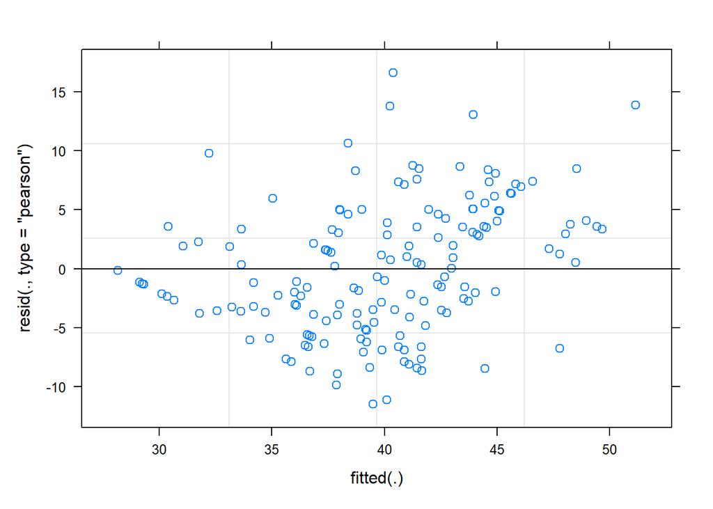

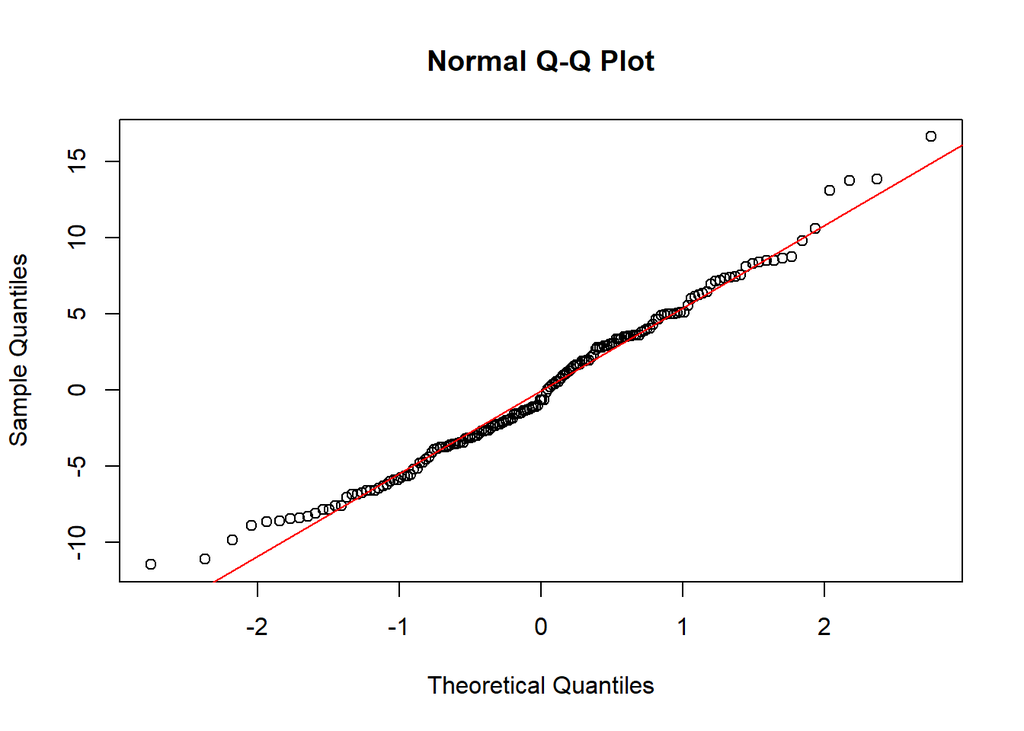

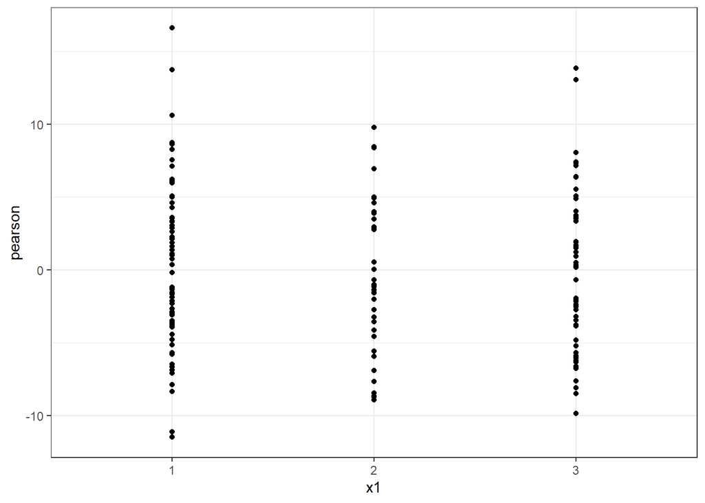

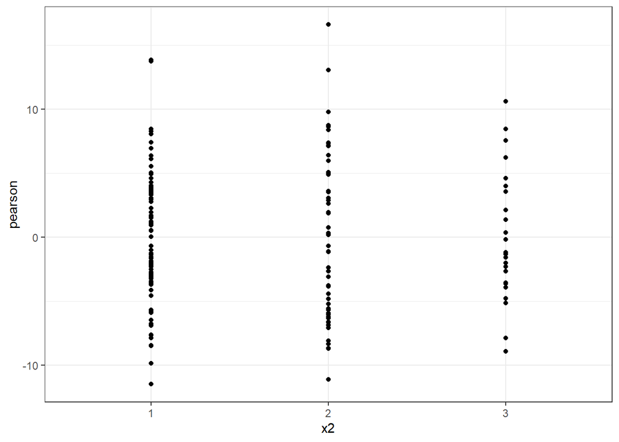

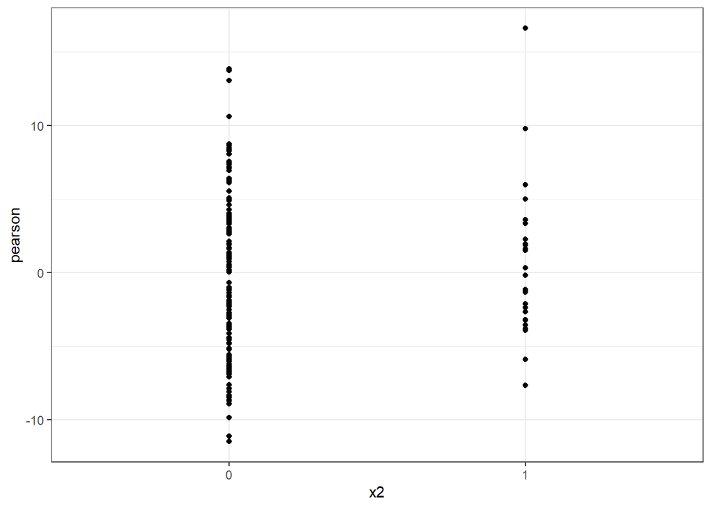

```r
rm(list = ls())
```